# Don’t Get Kicked - Kaggle

Alex Caico, Ghazal Erfani, Colton Mouritsen, Benjamin Turner

December 12, 2018

## Business Problem and Data Introduction

Used car dealers often make bad decisions when purchasing used cars at auctions. Our project is to use the Don’t Get Kicked competition dataset from Kaggle to help improve the decision making ability of used car dealers by decreasing their odds of purchasing a lemon vehicle. The data includes 34 variables ranging from the Make and Model, size, price, and a binary variable stating whether the vehicle was considered a lemon. A lemon is a vehicle that has unforeseen issues that result in the car not being able to be sold by the dealer. These issues include odometer tampering, unexpected mechanical problems, or issues related to getting the vehicle title from the seller. Lemons are very costly to dealers, as they have to somehow recover from the cost to transport the vehicle from the auction, repairs of any mechanical problems, and of course, the loss from being unable to resell the vehicle.

Our goal is to predict lemons, and to provide a detailed analysis on the data and build a model that helps tell the story about vehicles at auction. This will help dealers make better informed decisions and decrease the probability of buying a lemon.

## Data Transformation

```r
car_data$RefId=NULL
car_data$PurchDate=NULL
car_data$VehYear=NULL
car_data$BYRNO=NULL
car_data$VNZIP1=NULL
car_data$WheelTypeID=NULL
```

# Missing values

Conducting a quick analysis of null values as well as unique variable values reveals that no variable has nulls with the exception of [Trim], which has over 2000. Further, [Trim] has 135 unique values. Since the high number of unique values reduces [Trim]’s predictive power, and since it is unique in the number of nulls it contains, we opt to remove it completely from the dataset.

```r
suppressMessages(library(skimr))
skimmed <- skim_to_wide(car_data)
skimmed[, c(1:4, 6,7,9)]
```

```
## # A tibble: 28 x 7
##    type   variable      missing complete n_unique top_counts         mean
##    <chr>  <chr>         <chr>   <chr>    <chr>    <chr>              <chr>
##  1 factor AUCGUART      0       72983    3        NUL: 69564, GRE: ~ <NA>
##  2 factor Auction       0       72983    3        MAN: 41043, OTH: ~ <NA>
##  3 factor Color         0       72983    17       SIL: 14875, WHI: ~ <NA>
##  4 factor Make          0       72983    33       CHE: 17248, DOD: ~ <NA>
##  5 factor MMRAcquisiti~ 0       72983    10343    0: 828, 548: 368,~ <NA>
##  6 factor MMRAcquisiti~ 0       72983    11380    0: 697, 646: 374,~ <NA>
##  7 factor MMRAcquisiti~ 0       72983    12726    0: 828, 641: 369,~ <NA>
##  8 factor MMRAcquisito~ 0       72983    13457    0: 828, 747: 373,~ <NA>
##  9 factor MMRCurrentAu~ 0       72983    10316    0: 504, NUL: 315,~ <NA>
## 10 factor MMRCurrentAu~ 0       72983    11266    0: 378, NUL: 315,~ <NA>
## # ... with 18 more rows
```

```r
car_data$Trim=NULL
```

At the conclusion of running these regex operations, we delete the [Model] ad [SubModel] variables.

```r
suppressMessages(library(tidymodels))
suppressMessages(library(tidyverse))
suppressMessages(library(DataExplorer))
suppressMessages(library(ggplot2))

#Changed IsBadBuy values to levels "GoodBuy" and "BadBuy"
car_data <- car_data %>%
  mutate(IsBadBuy = ifelse(IsBadBuy == 0, "GoodBuy", "BadBuy"))
car_data$IsBadBuy <- as.factor(car_data$IsBadBuy)


#Binary variable changed to be a factor
car_data <- car_data %>%
  mutate(IsOnlineSale = ifelse(IsOnlineSale == 0, "No", "Yes"))
car_data$isOnlineSale <- as.factor(car_data$IsOnlineSale)


car_data$Doors = "4D"
car_data$Doors[grep("2d",car_data$SubModel,ignore.case=TRUE, fixed=FALSE)] = "2D"
car_data$Doors[grep("5d",car_data$SubModel,ignore.case=TRUE, fixed=FALSE)] = "5D"
car_data$Type = "PASSENGER"
car_data$Type[grep("MINIVAN",car_data$SubModel,ignore.case=TRUE, fixed=FALSE)] = "MINIVAN"
car_data$Type[grep("SUV",car_data$SubModel,ignore.case=TRUE, fixed=FALSE)] = "SUV"
car_data$Type[grep("WAGON",car_data$SubModel,ignore.case=TRUE, fixed=FALSE)] = "WAGON"
car_data$Type[grep("CARGO",car_data$SubModel,ignore.case=TRUE, fixed=FALSE)] = "CARGO"
car_data$Type[grep("SEDAN",car_data$SubModel,ignore.case=TRUE, fixed=FALSE)] = "SEDAN"
car_data$Type[grep("UTILITY",car_data$SubModel,ignore.case=TRUE, fixed=FALSE)] = "UTILITY"
car_data$Type[grep("COUPE",car_data$SubModel,ignore.case=TRUE, fixed=FALSE)] = "COUPE"
car_data$Type[grep("HATCHBACK",car_data$SubModel,ignore.case=TRUE, fixed=FALSE)] = "HATCHBACK"
car_data$Type[grep("CROSSOVER",car_data$SubModel,ignore.case=TRUE, fixed=FALSE)] = "CROSSOVER"
car_data$Type[grep("SUV-PICKUP",car_data$SubModel,ignore.case=TRUE, fixed=FALSE)] = "SUV-PICKUP"
car_data$Powertrain = "FWD"
car_data$Powertrain[grep("RWD",car_data$Model,ignore.case=TRUE, fixed=FALSE)] = "RWD"
car_data$Powertrain = "2WD"
car_data$Powertrain[grep("4WD",car_data$Model,ignore.case=TRUE, fixed=FALSE)] = "4WD"
car_data$Cyl = "V4"
car_data$Cyl[grep("V6",car_data$Model,ignore.case=TRUE, fixed=FALSE)] = "V6"
car_data$Cyl[grep("V8",car_data$Model,ignore.case=TRUE, fixed=FALSE)] = "V8"
car_data$Cyl[grep("V10",car_data$Model,ignore.case=TRUE, fixed=FALSE)] = "V10"
car_data$Cyl[grep("V10",car_data$Model,ignore.case=TRUE, fixed=FALSE)] = "V12"
car_data$Model=NULL
car_data$SubModel=NULL
car_data$PRIMEUNIT=NULL
car_data$AUCGUART=NULL


#Numerical data, which was read from csv as categorical. Changed to integers.
car_data <- transform(car_data, MMRAcquisitionAuctionAveragePrice = as.integer(MMRAcquisitionAuctionAveragePrice),
                      MMRAcquisitionAuctionCleanPrice = as.integer(MMRAcquisitionAuctionCleanPrice),
                      MMRAcquisitionRetailAveragePrice = as.integer(MMRAcquisitionRetailAveragePrice),
                      MMRAcquisitonRetailCleanPrice = as.integer(MMRAcquisitonRetailCleanPrice),
                      MMRCurrentAuctionAveragePrice = as.integer(MMRCurrentAuctionAveragePrice),
                      MMRCurrentAuctionCleanPrice   = as.integer(MMRCurrentAuctionCleanPrice),
                      MMRCurrentRetailAveragePrice = as.integer(MMRCurrentRetailAveragePrice),
                      MMRCurrentRetailCleanPrice = as.integer(MMRCurrentRetailCleanPrice)
                      )
```

## Exploratory Data Analysis

After initial data transformation, exploratory data analysis was conducted to further understand the data.

```r
car_data$Auction <- as.factor(car_data$Auction)
car_data$Make <- as.factor(car_data$Make)
car_data$Color <- as.factor(car_data$Color)
car_data$Transmission <- as.factor(car_data$Transmission)
car_data$Nationality <- as.factor(car_data$Nationality)
car_data$Size <- as.factor(car_data$Size)
car_data$TopThreeAmericanName <- as.factor(car_data$TopThreeAmericanName)
car_data$VNST <- as.factor(car_data$VNST)
car_data$Doors <- as.factor(car_data$Doors)
car_data$Type <- as.factor(car_data$Type)
car_data$Cyl <- as.factor(car_data$Cyl)

print("MMRAcquisitionAuctionAveragePrice Summary:")
```

```
## [1] "MMRAcquisitionAuctionAveragePrice Summary:"
```

```r
summary(car_data$MMRAcquisitionAuctionAveragePrice)
```

```
##    Min. 1st Qu.  Median    Mean 3rd Qu.    Max.
##       1    4268    6050    5904    7800   10343
```

```r
print("MMRAcquisitionAuctionCleanPrice Summary:")
```

```
## [1] "MMRAcquisitionAuctionCleanPrice Summary:"
```

```r
summary(car_data$MMRAcquisitionAuctionCleanPrice)
```

```
##    Min. 1st Qu.  Median    Mean 3rd Qu.    Max.
##       1    5470    7588    6979    9394   11380
```

```r
print("MMRAcquisitionRetailAveragePrice Summary:")
```

```
## [1] "MMRAcquisitionRetailAveragePrice Summary:"
```

```r
summary(car_data$MMRAcquisitionRetailAveragePrice)
```

```
##    Min. 1st Qu.  Median    Mean 3rd Qu.    Max.
##       1    2743    8266    7090   10608   12726
```

```r
print("MMRAcquisitonRetailCleanPrice Summary:")
```

```
## [1] "MMRAcquisitonRetailCleanPrice Summary:"
```

```r
summary(car_data$MMRAcquisitonRetailCleanPrice)
```

```
##    Min. 1st Qu.  Median    Mean 3rd Qu.    Max.
##       1    2215    7896    6846   11168   13457
```

```r
print("MMRCurrentAuctionAveragePrice Summary:")
```

```
## [1] "MMRCurrentAuctionAveragePrice Summary:"
```

```r
summary(car_data$MMRCurrentAuctionAveragePrice)
```

```
##    Min. 1st Qu.  Median    Mean 3rd Qu.    Max.
##       1    4273    6061    5916    7778   10316
```

```r
print("MMRCurrentAuctionCleanPrice Summary:")
```

```
## [1] "MMRCurrentAuctionCleanPrice Summary:"
```

```r
summary(car_data$MMRCurrentAuctionCleanPrice)
```

```
##    Min. 1st Qu.  Median    Mean 3rd Qu.    Max.
##       1    5437    7513    6940    9308   11266
```

```r
print("MMRCurrentRetailAveragePrice Summary:")
```

```
## [1] "MMRCurrentRetailAveragePrice Summary:"
```

```r
summary(car_data$MMRCurrentRetailAveragePrice)
```

```
##    Min. 1st Qu.  Median    Mean 3rd Qu.    Max.
##       1    2373    8062    6833   10413   12494
```

```r
print("MMRCurrentRetailCleanPrice Summary:")
```

```
## [1] "MMRCurrentRetailCleanPrice Summary:"
```

```r
summary(car_data$MMRCurrentRetailCleanPrice)
```

```
##    Min. 1st Qu.  Median    Mean 3rd Qu.    Max.
##       1    2142    6408    6566   10953   13193
```

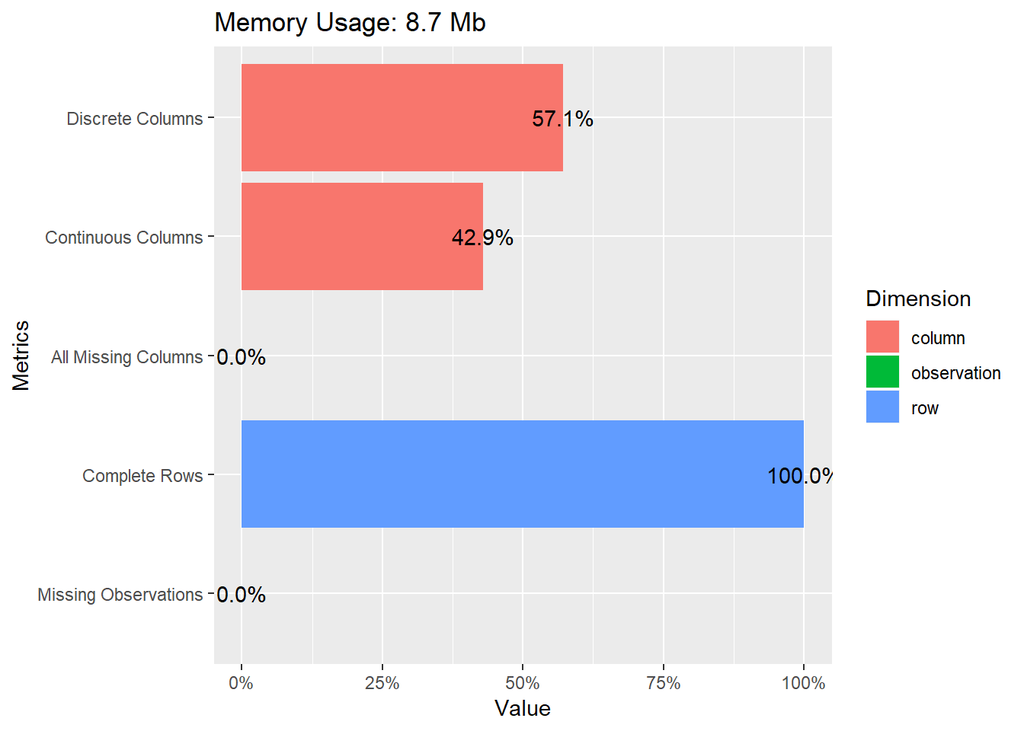

```r
#Converting NULL values to NA
car_data$Nationality[grep("NULL",car_data$Nationality,ignore.case=TRUE, fixed=FALSE)] = NA
car_data$Transmission[grep("NULL",car_data$Transmission,ignore.case=TRUE, fixed=FALSE)] = NA

plot_intro(car_data)
```

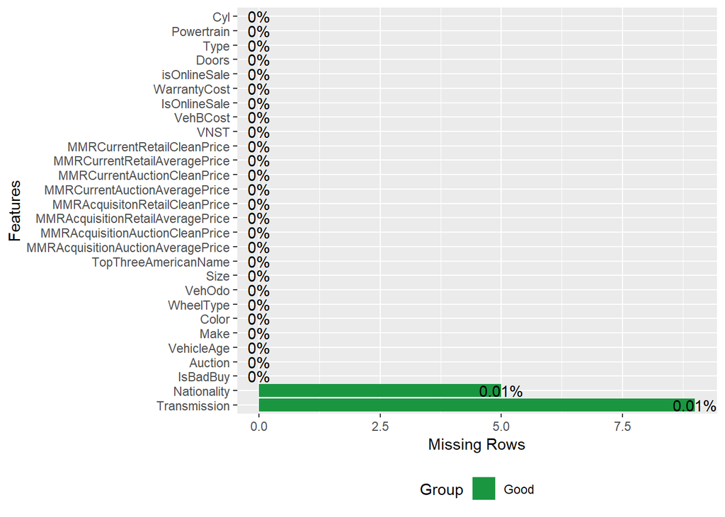

```r
plot_missing(car_data)
```

```r
row.has.na <- apply(car_data, 1, function(x){any(is.na(x))})
car_data <- car_data[!row.has.na,]
```

Distribution of continuous variables

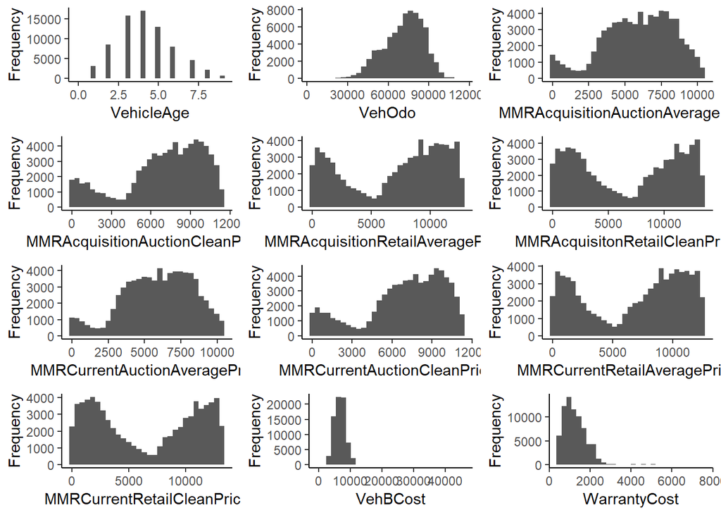

```r
plot_histogram(car_data, ggtheme = theme_classic())
```

```r
table(car_data$IsBadBuy)
```

```
##
##  BadBuy GoodBuy
##    8975   63994
```

```r
percent_lemons <- round(length(car_data$IsBadBuy[car_data$IsBadBuy == "BadBuy"]) / length(car_data$IsBadBuy) * 100,2)
cat("Percentage of Cars that are Lemons: ", percent_lemons, "%")
```

```
## Percentage of Cars that are Lemons:  12.3 %
```

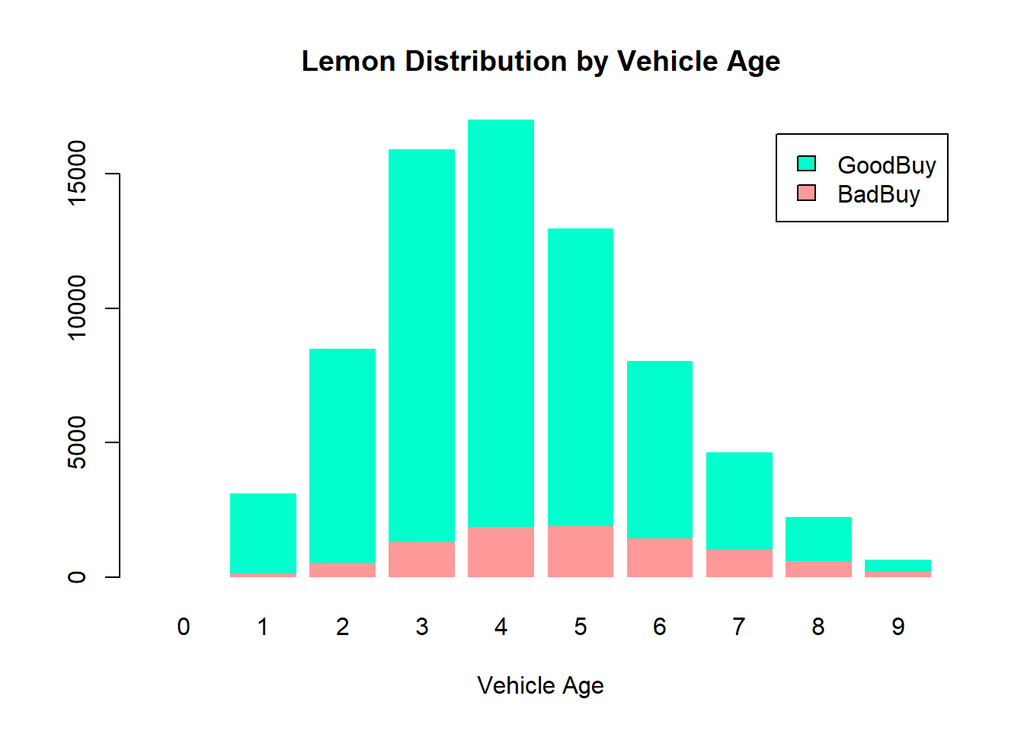

```r
counts_age <- table(car_data$IsBadBuy, car_data$VehicleAge)
barplot(counts_age, main="Lemon Distribution by Vehicle Age",
  xlab="Vehicle Age", col=c("#ff9999","#00ffcc"), border=NA,
    legend = rownames(counts_age))
```

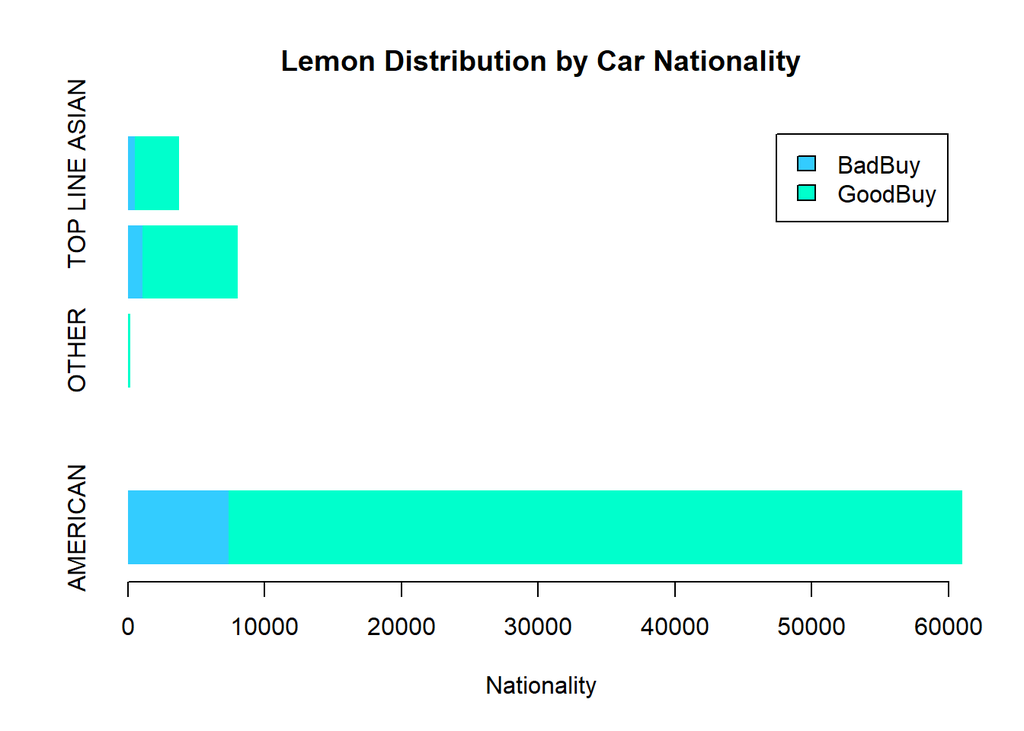

```r
counts_age <- table(car_data$IsBadBuy, car_data$Nationality)
p <- barplot(counts_age, main="Lemon Distribution by Car Nationality",
  xlab="Nationality", col=c("#33ccff","#00ffcc"), border=NA, horiz = TRUE,
    legend = rownames(counts_age))
```

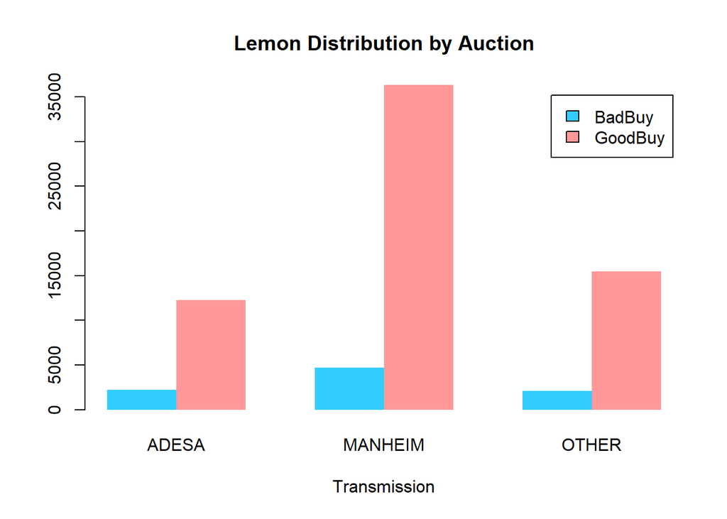

```r
counts <- table(car_data$IsBadBuy, car_data$Auction)
p <- barplot(counts, main="Lemon Distribution by Auction",
  xlab="Transmission", col=c("#33ccff","#ff9999"), border=NA,
    legend = rownames(counts), beside=TRUE)
```

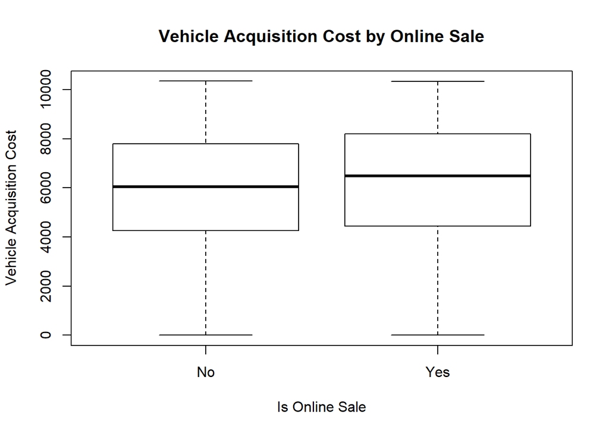

```r
boxplot(MMRAcquisitionAuctionAveragePrice~IsOnlineSale,data=car_data, main="Vehicle Acquisition Cost by Online Sale",
    xlab="Is Online Sale", ylab="Vehicle Acquisition Cost")
```

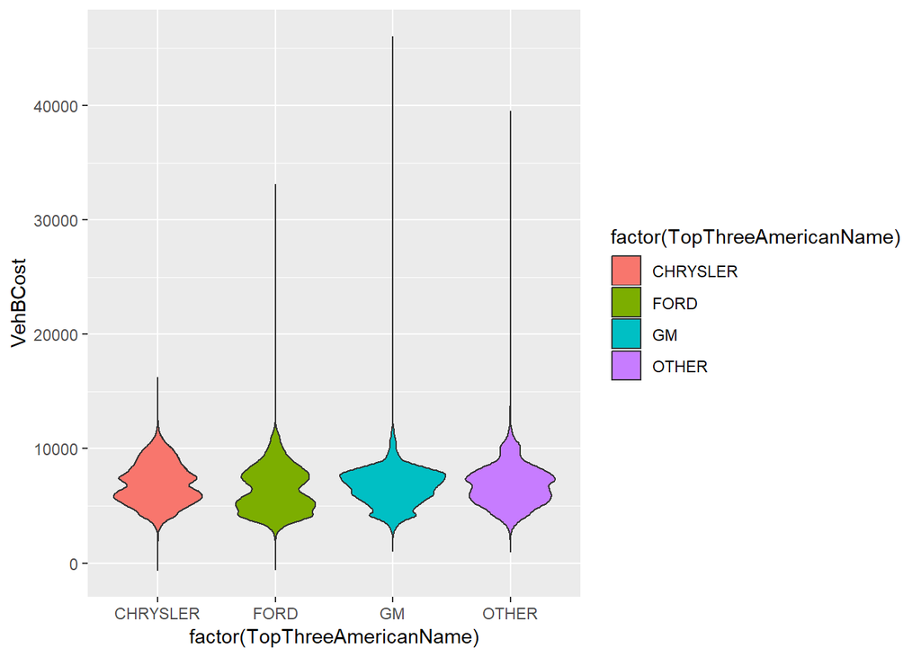

```r
library(ggplot2)
p <- ggplot(car_data, aes(factor(TopThreeAmericanName), VehBCost))
p + geom_violin(aes(fill = factor(TopThreeAmericanName)), trim = FALSE)
```

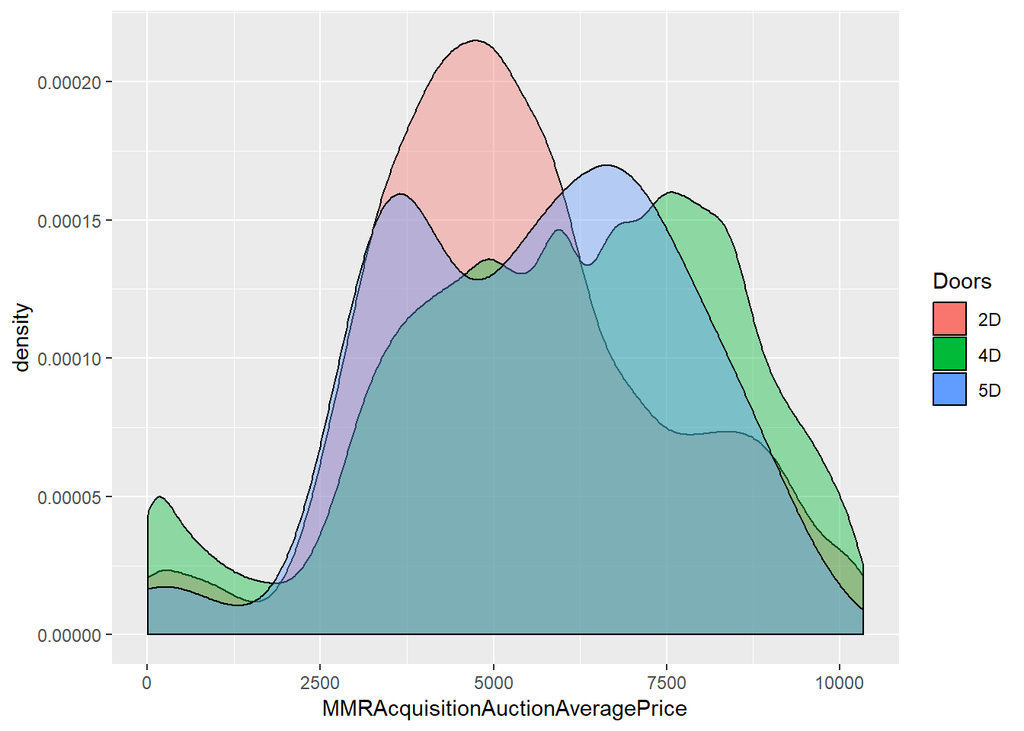

```r
ggplot(car_data, aes(x=MMRAcquisitionAuctionAveragePrice, fill = Doors, alpha = I(0.4))) + geom_density()
```

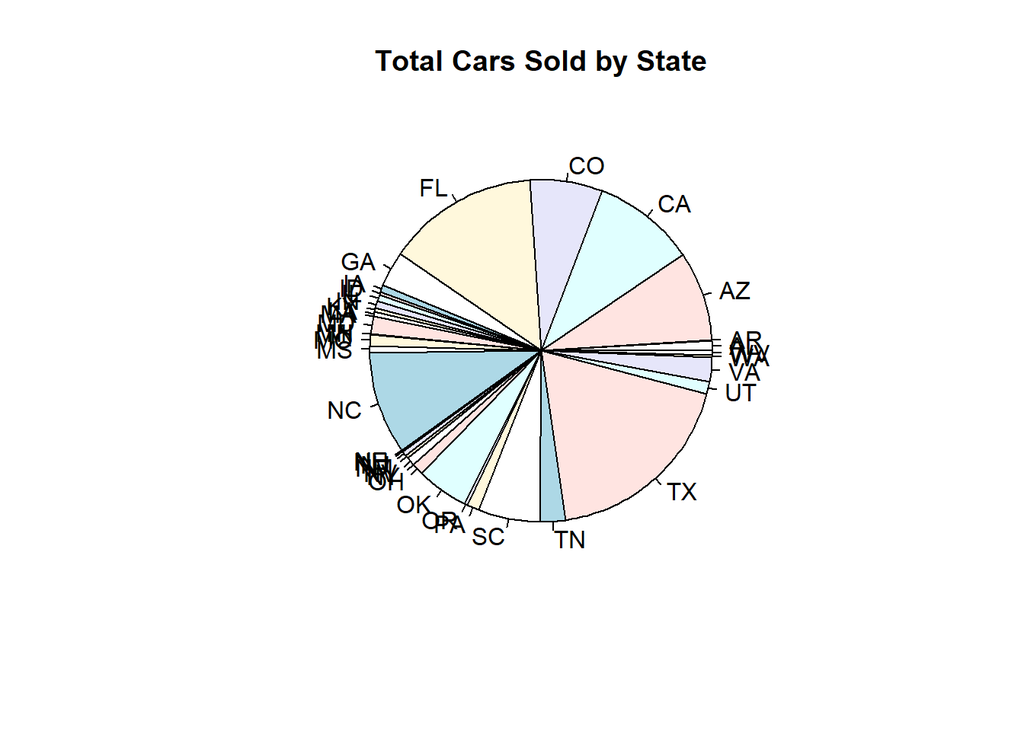

```r
pie(table(car_data$VNST), main = "Total Cars Sold by State")
```

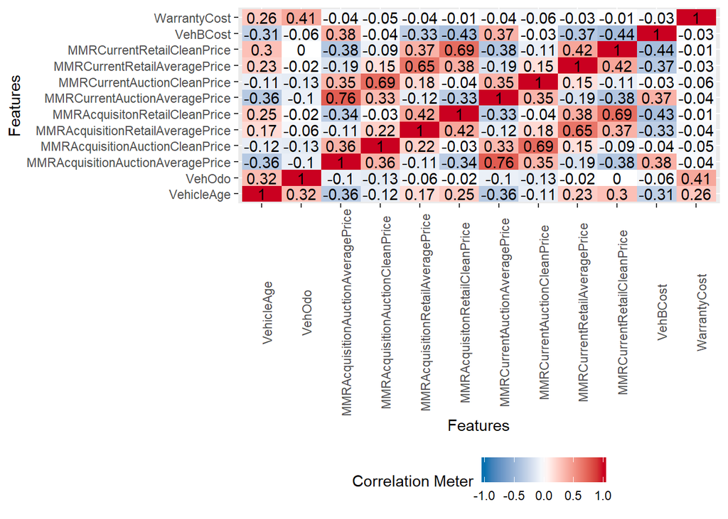

```r
plot_correlation(car_data, type = 'continuous')
```

## Splitting data between training and testing

Test data is not used during training, so the final model can be assessed with test data that the model hasn’t seen before

```r
set.seed(4595)
data_split <- initial_split(car_data)
car_train <- training(data_split)
car_test  <- testing(data_split)
nrow(car_train)/nrow(car_data)
```

```
## [1] 0.7500034
```

## Recipe Creation

```r
car_recipe <- recipe(IsBadBuy~., data=car_train) %>%
   step_center(all_numeric()) %>%
   step_scale(all_numeric())


car_train_prep <- prep(car_recipe, training=car_train, retain=TRUE, verbose=TRUE)
```

```
## oper 1 step center [training]
## oper 2 step scale [training]
```

```r
car_train_baked <- bake(car_train_prep,car_train)
```

## Modeling Method

The exploratory data analysis shows that we are attempting to predict a bivaraite classification problem and that there is a skewed distribution of the values of the target variable. There is 12.3% “BadBuys” in the overall data. It is more important to correctly to predict “BadBuys”. To account for this, we used down sampling and true class probs when training the model. Several models are being assessed for this bivariate classification problem -CART -Bagged CART -Naive Bayes -GCV MARS Earth -Bagged Logic Regression

Tuning Parameters for models to be assessed

```r
suppressMessages(library(caret))
modelLookup('rpart2')
```

```
##    model parameter          label forReg forClass probModel
## 1 rpart2  maxdepth Max Tree Depth   TRUE     TRUE      TRUE
```

```r
modelLookup('nb')
```

```
##   model parameter                label forReg forClass probModel
## 1    nb        fL   Laplace Correction  FALSE     TRUE      TRUE
## 2    nb usekernel    Distribution Type  FALSE     TRUE      TRUE
## 3    nb    adjust Bandwidth Adjustment  FALSE     TRUE      TRUE
```

```r
modelLookup('treebag')
```

```
##     model parameter     label forReg forClass probModel
## 1 treebag parameter parameter   TRUE     TRUE      TRUE
```

```r
modelLookup('gcvEarth')
```

```
##      model parameter          label forReg forClass probModel
## 1 gcvEarth    degree Product Degree   TRUE     TRUE      TRUE
```

```r
modelLookup('logicBag')
```

```
##      model parameter                    label forReg forClass probModel
## 1 logicBag   nleaves Maximum Number of Leaves   TRUE     TRUE      TRUE
## 2 logicBag    ntrees          Number of Trees   TRUE     TRUE      TRUE
```

## Train Control and Tune Grids for All Models

```r
ctrl <- trainControl(
  method = "cv",

  classProbs = TRUE,
  summaryFunction = twoClassSummary,
  savePredictions = "final",
  sampling = "down"
)

cart_grid <- expand.grid(
  data.frame(maxdepth = 1:10)
)


nb_smoothing_grid <- expand.grid(
  usekernel = TRUE,
  fL = 0,
  adjust = seq(2.0, 5.0, by = 0.5)
)


logic_grid = expand.grid(
   nleaves=20,
   ntrees=60)

logic_ctrl <- trainControl(
   method = "cv",
   # Also predict the probabilities
   classProbs = TRUE,
   verboseIter = TRUE,
   summaryFunction = twoClassSummary,
   savePredictions = "final",
   sampling = "down"
)
```

## Model Training & Performance Assessment

CART Model

```r
library("pROC")
cart_mod <- train(
  car_recipe,
  data = car_train,
  method = "rpart2",
  metric = "ROC",
  tuneGrid = cart_grid,
  trControl = ctrl
)

#Model Stats
cart_mod
```

```
## CART
##
## 54727 samples
##    27 predictor
##     2 classes: 'BadBuy', 'GoodBuy'
##
## Recipe steps: center, scale
## Resampling: Cross-Validated (10 fold)
## Summary of sample sizes: 49254, 49254, 49255, 49254, 49254, 49255, ...
## Addtional sampling using down-sampling
##
## Resampling results across tuning parameters:
##
##   maxdepth  ROC        Sens       Spec
##    1        0.6194205  0.2531157  0.9857253
##    2        0.7036403  0.6954006  0.6275660
##    3        0.7160898  0.5672107  0.7770656
##    4        0.7163069  0.5732938  0.7725855
##    5        0.7163928  0.5761128  0.7703971
##    6        0.7163928  0.5761128  0.7703971
##    7        0.7163928  0.5761128  0.7703971
##    8        0.7163928  0.5761128  0.7703971
##    9        0.7163928  0.5761128  0.7703971
##   10        0.7163928  0.5761128  0.7703971
##
## ROC was used to select the optimal model using the largest value.
## The final value used for the model was maxdepth = 5.
```

```r
confusionMatrix(cart_mod)
```

```
## Cross-Validated (10 fold) Confusion Matrix
##
## (entries are percentual average cell counts across resamples)
##
##           Reference
## Prediction BadBuy GoodBuy
##    BadBuy     7.1    20.1
##    GoodBuy    5.2    67.6
##
##  Accuracy (average) : 0.7465
```

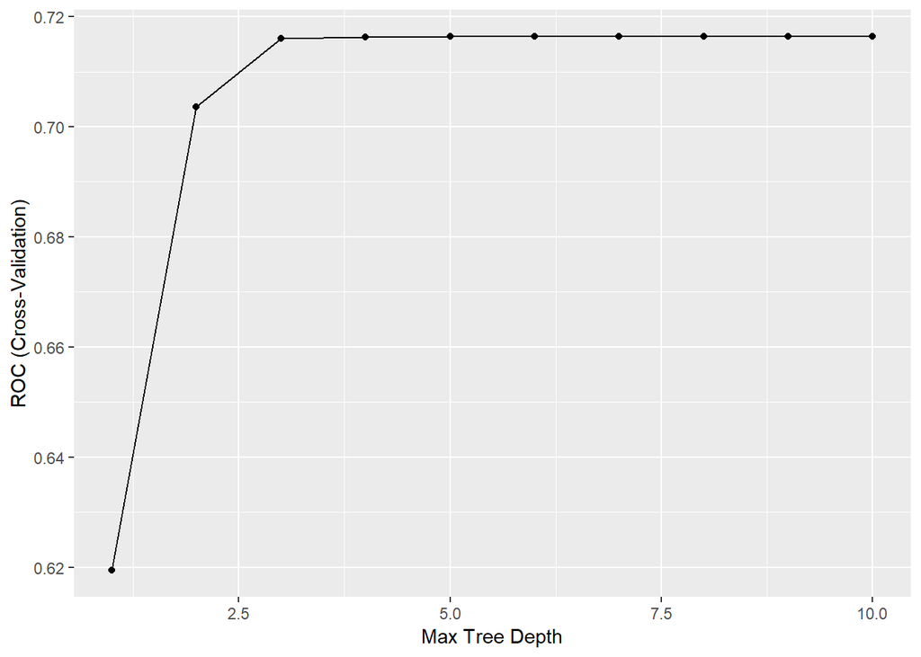

```r
ggplot(cart_mod) + theme(legend.position = "top")
```

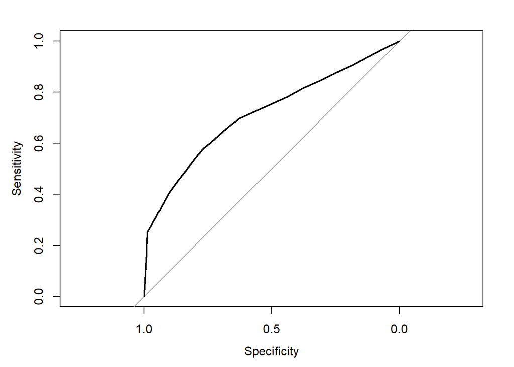

```r
#Create plot ROC function
plot_roc <- function(x, ...){
  roc_obj <- roc(
    response = x[["obs"]],
    predictor = x[["BadBuy"]],
    levels = rev(levels(x$obs))
  )
  plot(roc_obj, ...)
}

#Plot ROC
plot_roc(cart_mod$pred)
```

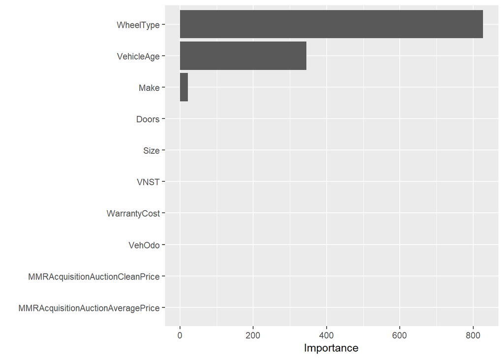

```r
#Variable Importance
cart_imp <- varImp(cart_mod, scale = FALSE,
                   surrogates = FALSE,
                   competes = FALSE)
ggplot(cart_imp, top = 10) + xlab("")
```

Bagged CART (treebag)

```r
cart_bagged_mod <- train(
  car_recipe,
  data = car_train,
  method = "treebag",
  metric = "ROC",
  trControl = ctrl

)
#Model Stats
cart_bagged_mod
```

```
## Bagged CART
##
## 54727 samples
##    27 predictor
##     2 classes: 'BadBuy', 'GoodBuy'
##
## Recipe steps: center, scale
## Resampling: Cross-Validated (10 fold)
## Summary of sample sizes: 49255, 49254, 49254, 49254, 49254, 49254, ...
## Addtional sampling using down-sampling
##
## Resampling results:
##
##   ROC        Sens       Spec
##   0.7337298  0.6274481  0.7024195
```

```r
confusionMatrix(cart_bagged_mod)
```

```
## Cross-Validated (10 fold) Confusion Matrix
##
## (entries are percentual average cell counts across resamples)
##
##           Reference
## Prediction BadBuy GoodBuy
##    BadBuy     7.7    26.1
##    GoodBuy    4.6    61.6
##
##  Accuracy (average) : 0.6932
```

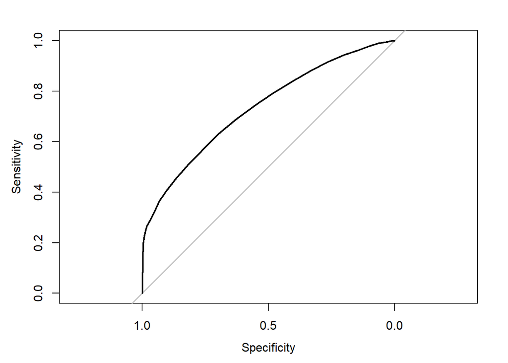

```r
#Plot ROC
plot_roc(cart_bagged_mod$pred)
```

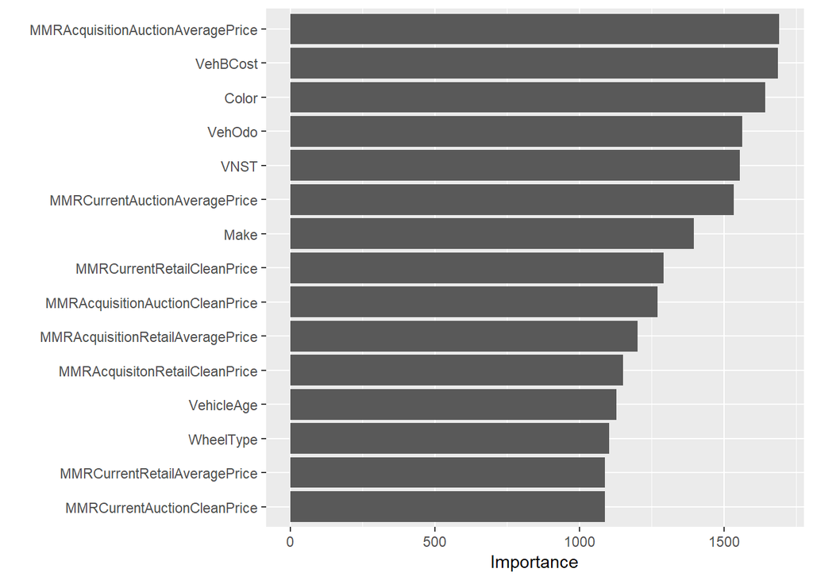

```r
#Variable Importance
cart_bagged_imp <- varImp(cart_bagged_mod, scale = FALSE)
ggplot(cart_bagged_imp, top = 15) + xlab("")
```

Naive Bayes

```r
nb_mod <- train(
  car_recipe,
  data = car_train,
  method = "nb",
  metric = "ROC",
  tuneGrid = nb_smoothing_grid,
  trControl = ctrl
)
#Model Stats
nb_mod
```

```
## Naive Bayes
##
## 54727 samples
##    27 predictor
##     2 classes: 'BadBuy', 'GoodBuy'
##
## Recipe steps: center, scale
## Resampling: Cross-Validated (10 fold)
## Summary of sample sizes: 49254, 49254, 49254, 49255, 49254, 49254, ...
## Addtional sampling using down-sampling
##
## Resampling results across tuning parameters:
##
##   adjust  ROC        Sens       Spec
##   2.0     0.6917639  0.6176558  0.6464040
##   2.5     0.6944266  0.6316024  0.6357135
##   3.0     0.6980930  0.6464392  0.6279825
##   3.5     0.7000594  0.6590504  0.6128326
##   4.0     0.7043877  0.6737389  0.6016421
##   4.5     0.7072626  0.6844214  0.5929312
##   5.0     0.7105821  0.7023739  0.5793234
##
## Tuning parameter 'fL' was held constant at a value of 0
## Tuning
##  parameter 'usekernel' was held constant at a value of TRUE
## ROC was used to select the optimal model using the largest value.
## The final values used for the model were fL = 0, usekernel = TRUE
##  and adjust = 5.
```

```r
confusionMatrix(nb_mod)
```

```
## Cross-Validated (10 fold) Confusion Matrix
##
## (entries are percentual average cell counts across resamples)
##
##           Reference
## Prediction BadBuy GoodBuy
##    BadBuy     8.7    36.9
##    GoodBuy    3.7    50.8
##
##  Accuracy (average) : 0.5945
```

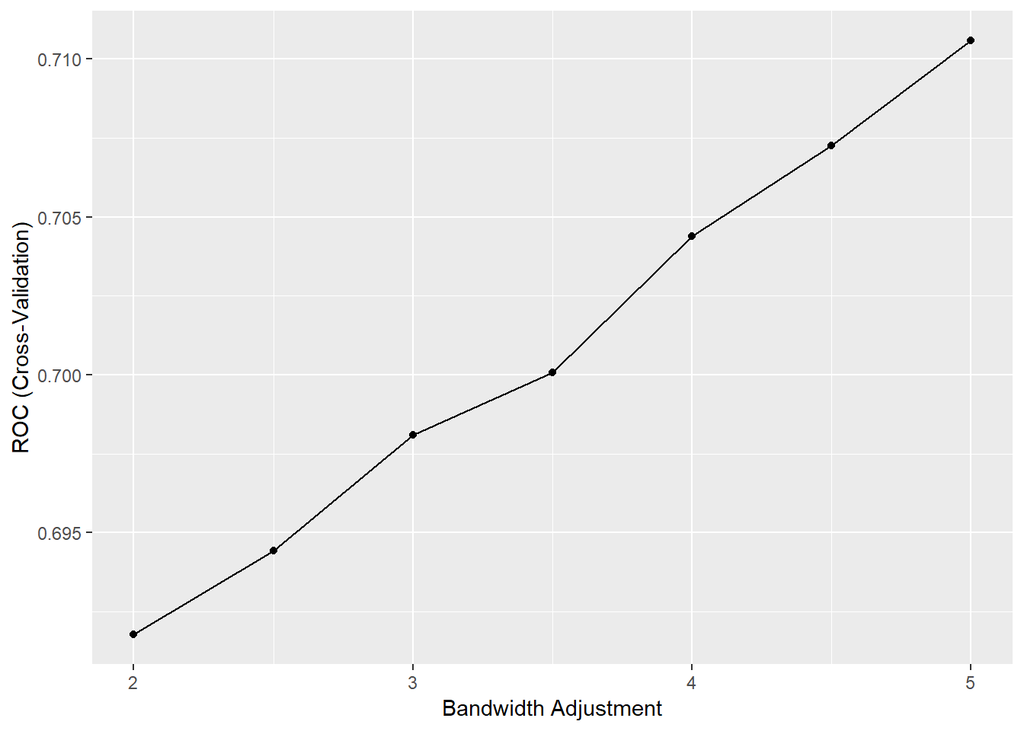

```r
ggplot(nb_mod) + theme(legend.position = "top")
```

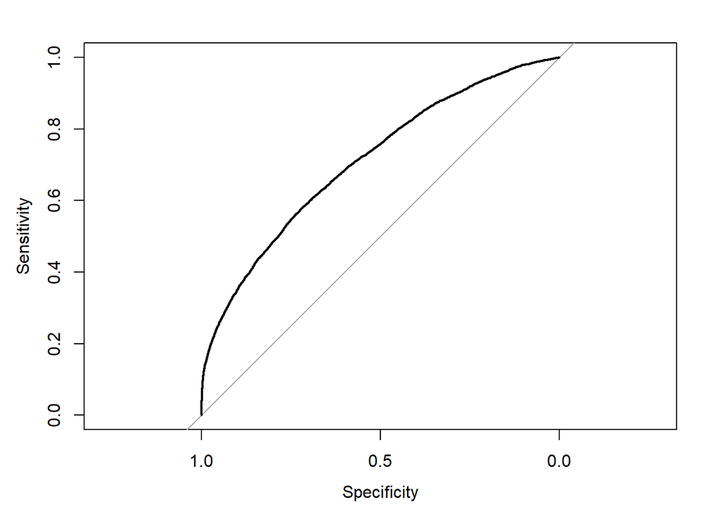

```r
#Plot ROC
plot_roc(nb_mod$pred)
```

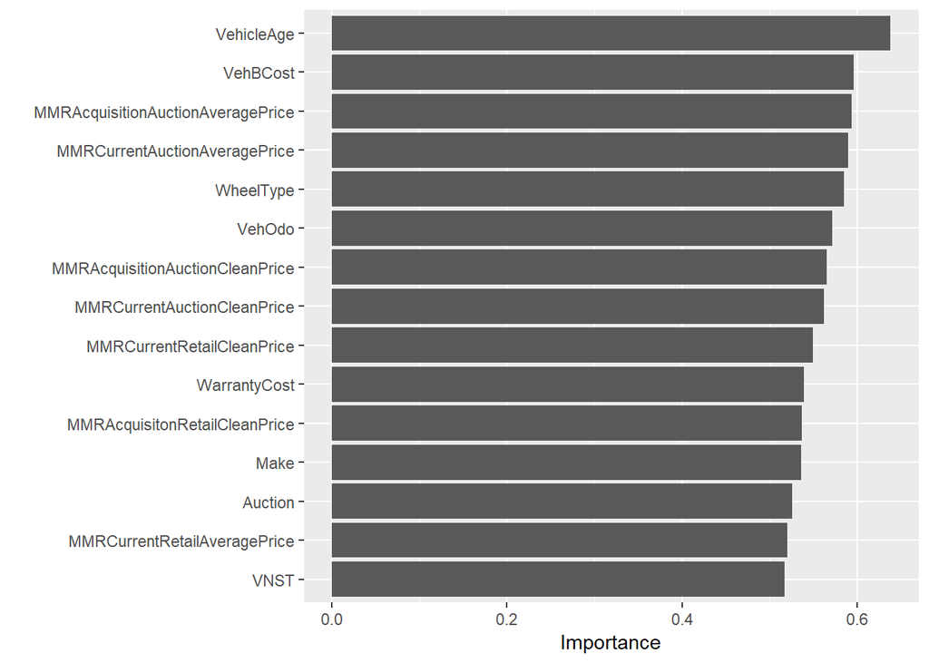

```r
#Variable Importance
nb_imp <- varImp(nb_mod, scale = FALSE,
                   surrogates = FALSE,
                   competes = FALSE)
ggplot(nb_imp, top = 15) + xlab("")
```

Logistics Regression

```r
# library(LogicReg)
# library(mcbiopi)
# library(logicFS)
#
# set.seed(5515)
# logic_mod = train(
#  #  car_recipe,
#    data = car_train_baked,
#    x = car_train_baked[, names(car_train_baked) == "Auction_MANHEIM"],
#    y = car_train_baked$IsBadBuy_GoodBuy,
#    method = "logicBag",
#    metric = "ROC",
#    tuneGrid = logic_grid,
#    trControl = logic_ctrl
# )

##Errors with log regression that we couldn't solve
```

GCV MARS

```r
library(earth)
set.seed(3544)
mars_gcv_mod <- train(
  car_recipe,
  data = car_train,
  method = "gcvEarth",
  tuneGrid = data.frame(degree = 1:2),
  metric = "ROC",
  trControl = ctrl
)

mars_gcv_mod$finalModel
```

```
## Earth selected 25 of 29 terms, and 14 of 141 predictors
## Termination condition: RSq changed by less than 0.001 at 29 terms
## Importance: WheelTypeNULL, VehicleAge, VehBCost, VehOdo, ...
## Number of terms at each degree of interaction: 1 7 17
## Earth GCV 0.1981115    RSS 2646.429    GRSq 0.2076714    RSq 0.2147096
##
## GLM null.deviance 18687.25 (13479 dof)   deviance 15301.8 (13455 dof)   iters 6
```

```r
mars_gcv_mod
```

```
## Multivariate Adaptive Regression Splines
##
## 54727 samples
##    27 predictor
##     2 classes: 'BadBuy', 'GoodBuy'
##
## Recipe steps: center, scale
## Resampling: Cross-Validated (10 fold)
## Summary of sample sizes: 49254, 49255, 49255, 49255, 49254, 49254, ...
## Addtional sampling using down-sampling
##
## Resampling results across tuning parameters:
##
##   degree  ROC        Sens       Spec
##   1       0.7494209  0.5940653  0.7638526
##   2       0.7502421  0.5980712  0.7568713
##
## ROC was used to select the optimal model using the largest value.
## The final value used for the model was degree = 2.
```

```r
confusionMatrix(mars_gcv_mod)
```

```
## Cross-Validated (10 fold) Confusion Matrix
##
## (entries are percentual average cell counts across resamples)
##
##           Reference
## Prediction BadBuy GoodBuy
##    BadBuy     7.4    21.3
##    GoodBuy    5.0    66.4
##
##  Accuracy (average) : 0.7373
```

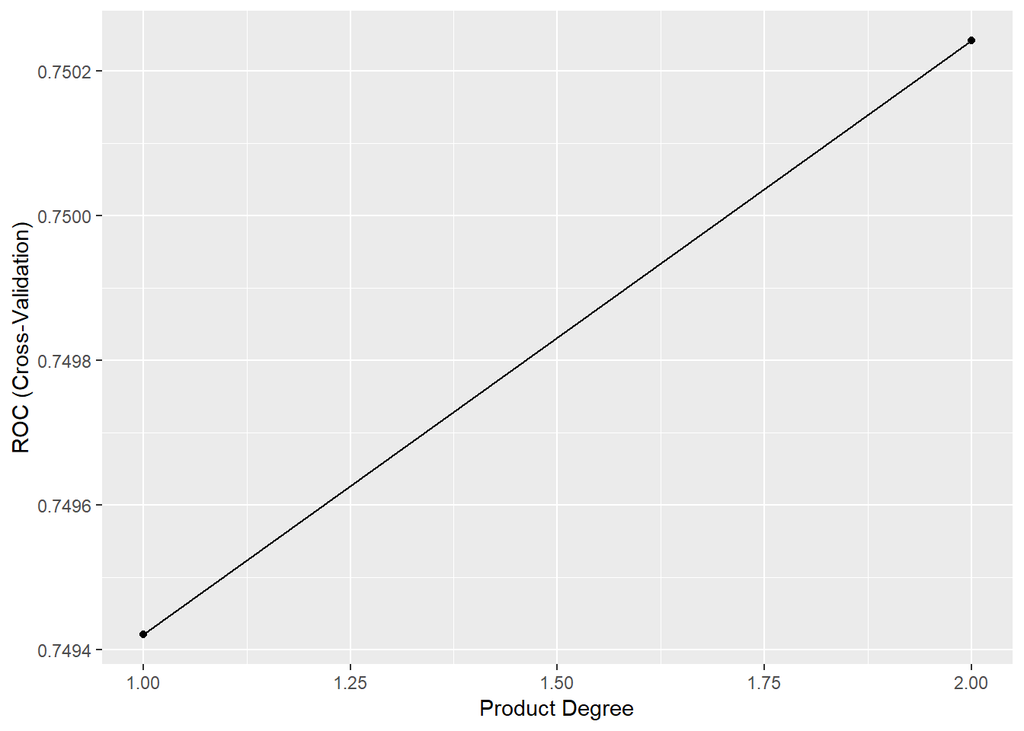

```r
ggplot(mars_gcv_mod) + theme(legend.position = "top")
```

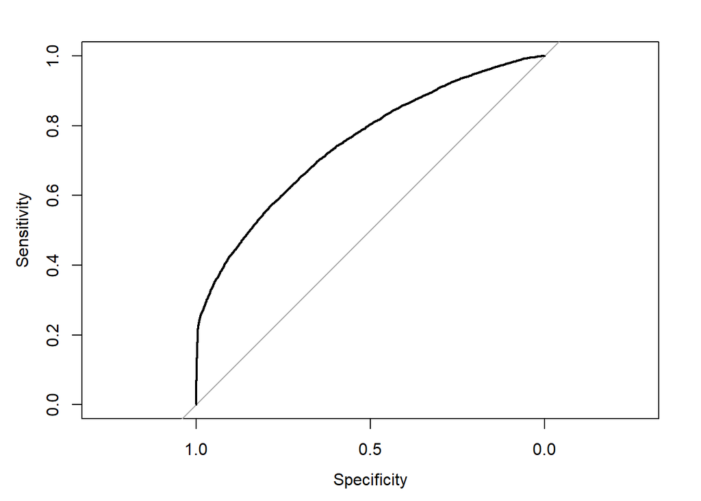

```r
plot_roc(mars_gcv_mod$pred)
```

## Model Comparisons with TidyPosterior

```r
suppressMessages(library(tidyposterior))
rs <- resamples(
  list(CART = cart_mod, Bagged = cart_bagged_mod, Bayes = nb_mod, GCV = mars_gcv_mod )
)

suppressMessages(roc_mod <- perf_mod(rs, seed = 2560, iter = 5000))
differences <- contrast_models(
  roc_mod,
  list_1 = c("Bagged", "Bagged", "Bagged", "GCV", "GCV", "CART"),
  list_2 = c("Bayes", "GCV", "CART", "Bayes", "CART", "Bayes"),
  seed = 650
)

roc_dist <- tidy(roc_mod)
summary(roc_dist)
```

```
## # A tibble: 4 x 4
##   model   mean lower upper
##   <chr>  <dbl> <dbl> <dbl>
## 1 Bagged 0.734 0.727 0.740
## 2 Bayes  0.711 0.704 0.717
## 3 CART   0.717 0.710 0.723
## 4 GCV    0.750 0.743 0.756
```

```r
summary(differences, size = 0.025)
```

```
## # A tibble: 6 x 9
##   contrast probability     mean    lower    upper  size pract_neg
##   <chr>          <dbl>    <dbl>    <dbl>    <dbl> <dbl>     <dbl>
## 1 Bagged ~     1        0.0229   0.0140   0.0317  0.025    0
## 2 Bagged ~     0.999    0.0170   0.00794  0.0259  0.025    0
## 3 Bagged ~     0.00120 -0.0164  -0.0254  -0.00747 0.025    0.0577
## 4 CART vs~     0.866    0.00596 -0.00291  0.0149  0.025    0
## 5 GCV vs ~     1        0.0393   0.0305   0.0481  0.025    0
## 6 GCV vs ~     1        0.0334   0.0243   0.0422  0.025    0
## # ... with 2 more variables: pract_equiv <dbl>, pract_pos <dbl>
```

[figure not shown]

```r
differences %>%
  mutate(contrast = paste(model_2, "vs", model_1)) %>%
  ggplot(aes(x = difference, col = contrast)) +
  geom_line(stat = "density") +
  geom_vline(xintercept = c(-0.025, 0.025), lty = 2)
```

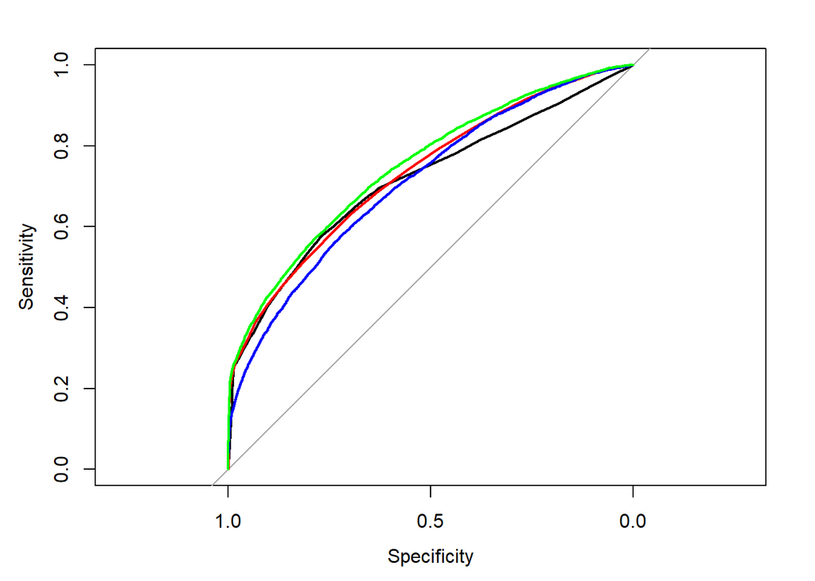

```r
plot_roc(cart_mod$pred)
plot_roc(cart_bagged_mod$pred, col = "red", add = TRUE)
plot_roc(nb_mod$pred, col = "blue", add = TRUE)
plot_roc(mars_gcv_mod$pred, col = "green", add = TRUE)
```

Model Comparison Result: Tidyposterior compares the differences in model statistics through resampling. The results of the resampling is used to get parameter estimates for each model’s effect on the resampled ROC values and make statistical significant comparisons between models.

## Predicting on the Test Set

```r
suppressMessages(library(e1071))
suppressMessages(library(caTools))
suppressMessages(library(scales))

test_res <- car_test %>%
  dplyr::select(IsBadBuy) %>%
  mutate(
    prob = predict(mars_gcv_mod, car_test, type = "prob")[,"BadBuy"],
    pred = predict(mars_gcv_mod, car_test)
  )

roc_curve <- roc(test_res$IsBadBuy, test_res$prob, levels = c("GoodBuy", "BadBuy"))

getTrainPerf(mars_gcv_mod)
```

```
##    TrainROC TrainSens TrainSpec   method
## 1 0.7502421 0.5980712 0.7568713 gcvEarth
```

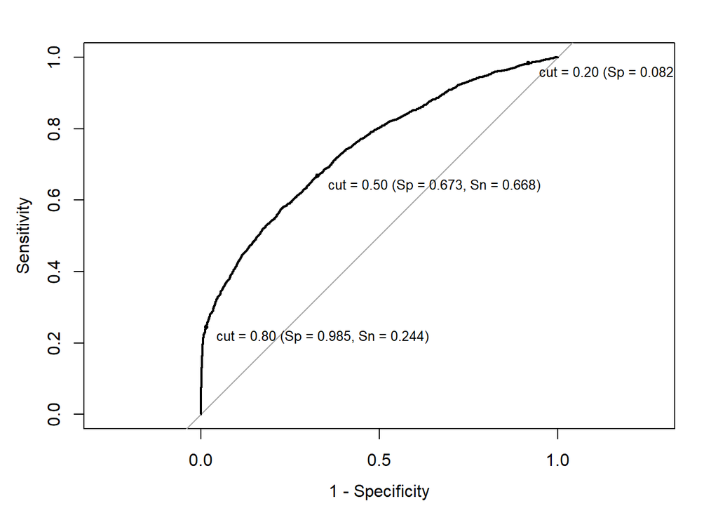

```r
plot(
    roc_curve,
    legacy.axes = TRUE,
    print.thres = c(.2, .5, .8),
    print.thres.pattern = "cut = %.2f (Sp = %.3f, Sn = %.3f)",
    print.thres.cex = .8
)
```

```r
car_test_predict <- predict(mars_gcv_mod, car_test)
cfm <- confusionMatrix(car_test_predict, car_test$IsBadBuy)
cfm
```

```
## Confusion Matrix and Statistics
##
##           Reference
## Prediction BadBuy GoodBuy
##    BadBuy    1492    5229
##    GoodBuy    743   10778
##
##                Accuracy : 0.6726
##                  95% CI : (0.6658, 0.6794)
##     No Information Rate : 0.8775
##     P-Value [Acc > NIR] : 1
##
##                   Kappa : 0.1829
##  Mcnemar's Test P-Value : <2e-16
##
##             Sensitivity : 0.66756
##             Specificity : 0.67333
##          Pos Pred Value : 0.22199
##          Neg Pred Value : 0.93551
##              Prevalence : 0.12252
##          Detection Rate : 0.08179
##    Detection Prevalence : 0.36844
##       Balanced Accuracy : 0.67045
##
##        'Positive' Class : BadBuy
##
```

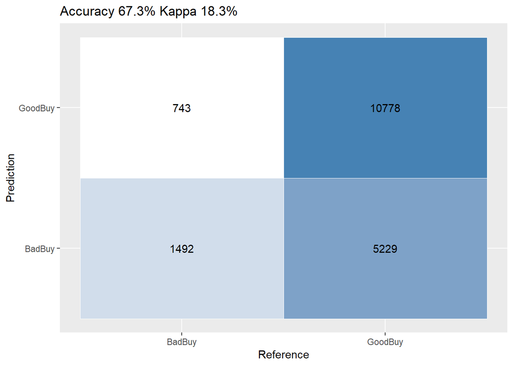

```r
ggplotConfusionMatrix <- function(m){
  mytitle <- paste("Accuracy", percent_format()(m$overall[1]),
                   "Kappa", percent_format()(m$overall[2]))
  p <-
    ggplot(data = as.data.frame(m$table) ,
           aes(x = Reference, y = Prediction)) +
    geom_tile(aes(fill = log(Freq)), colour = "white") +
    scale_fill_gradient(low = "white", high = "steelblue") +
    geom_text(aes(x = Reference, y = Prediction, label = Freq)) +
    theme(legend.position = "none") +
    ggtitle(mytitle)
  return(p)
}

ggplotConfusionMatrix(cfm)
```

Evaluation of Test Set: We have selected GCVearth as the best performing model from the training and cross validation. We have predicted the test data on this model. The model correctly predicted 1,492 Lemons (“Badbuy”) out of 2,235 lemons (67%) The model also incorrectly predicted good buys as Lemons 5,229 out of 16,007 good buys (33%).

Implementation This model could be integrated with a software application that would allow car dealers to send a request with specifc car details at an auction, so then the model could return a response whether it predicts the car to be a lemon or not. The user should use this response as an indicator to ask the auctioneer for more information or conduct additional inspection of the car before buying, to ensure it is not a lemon. After car dealers have bought a car and determined whether or not it was a lemon, they should enter this new data in the application and the models should be re-trained with this additional data, so the models could continuously learn overtime and detect any new trends in the data.